# `scikit-learn` Toy Datasets in Python: Wine recognition dataset

- For this dataset’s **description**, see [here](https://scikit-learn.org/stable/datasets/toy_dataset.html#wine-recognition-dataset)
- For this dataset’s **documentation**, see [here](https://scikit-learn.org/stable/modules/generated/sklearn.datasets.load_wine.html)

The wine recognition dataset is loaded using `load_wine()`. This returns a ‘Bunch’ object which contains both the data itself as well as metadata. By default the data is formatted as NumPy arrays but, by setting the `as_frame` parameter to `True` when loading the dataset, this can be changed so as to use Pandas data frames:

```python
from sklearn import datasets

# Load the dataset
wine = datasets.load_wine(as_frame=True)
```

The data contains results from the chemical analyses of 178 different wines, ie there are 178 *samples* or instances in the dataset. The wines came from 3 different cultivators in the same region of Italy, and this is the *target* or class information. There were 13 measurements taken during each analysis, so there are 13 *features* or attributes. So, when formatted as a data frame, the data consists of 178 rows and 13 + 1 columns (13 features and 1 target). The feature and target data can be extracted separately as two data frames or together in one data frame:

```python
# Extract the feature data only
features = wine['data']

# Extract the target data only
target = wine['target']

# Extract the feature and target data together
df = wine['frame']

print(df.head())
```

```
##    alcohol  malic_acid   ash  ...  od280/od315_of_diluted_wines  proline  target
## 0    14.23        1.71  2.43  ...                          3.92   1065.0       0
## 1    13.20        1.78  2.14  ...                          3.40   1050.0       0
## 2    13.16        2.36  2.67  ...                          3.17   1185.0       0
## 3    14.37        1.95  2.50  ...                          3.45   1480.0       0
## 4    13.24        2.59  2.87  ...                          2.93    735.0       0
##
## [5 rows x 14 columns]
```

The column names of the first 13 columns are the features names, and these are also available in in a separate `feature_names` array:

```python
print(wine['feature_names'])
```

```
## ['alcohol', 'malic_acid', 'ash', 'alcalinity_of_ash', 'magnesium', 'total_phenols', 'flavanoids', 'nonflavanoid_phenols', 'proanthocyanins', 'color_intensity', 'hue', 'od280/od315_of_diluted_wines', 'proline']
```

The column name of the 14th column is `target` which indicates that this is the target information, ie which cultivator the wine in question came from. These are simply the values `0`, `1` and `2`:

```python
print(df['target'].unique())
```

```
## [0 1 2]
```

# Example Usage

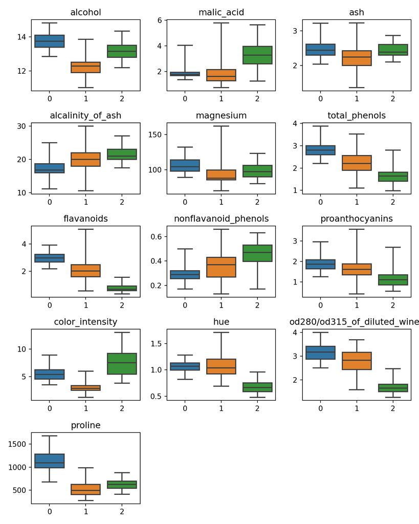

```python
from matplotlib import pyplot as plt
import seaborn as sns

fig, axs = plt.subplots(5, 3, figsize=(8, 10))
for i, ax in enumerate(fig.get_axes()):
    if i < 13:
        feature = wine['feature_names'][i]
        sns.boxplot(df, x='target', y=feature, whis=[0, 100], ax=ax)
        ax.set_title(feature)
        ax.set_ylabel('')
        ax.set_xlabel('')
fig.delaxes(axs[(4, 2)])
fig.delaxes(axs[(4, 1)])
plt.tight_layout()
plt.show()
```